# Getting the right number

John Paul Gosling, Durham University

2026-03-26

## Overview

| Segment | Approx. time |
| --- | --- |
| Why numbers matter; verbal probabilities | 20 min |
| From qualitative evidence to quantitative reasoning | 15 min |
| Naive approaches | 15 min |
| The effort of doing it well | 15 min |
| Monte Carlo simulation and correlation | 20 min |
| Defining the question precisely | 10 min |
| The role of quantitative analysis in decision-making | 15 min |
| Discussion and questions | 10 min |

## Your research question

Write down a research question from your PhD or current project that involves an uncertain claim: something where the answer is not known with certainty or where you are trying to estimate a quantity that varies or is hard to measure.

State it as you would normally write it.

Keep it. We will return to it at several points during the session.

# Why are numbers important?

[figure not shown]

*Source:* xkcd.com

## Why are numbers important?

- Decisions require **comparison**; numbers allow us to compare options, scenarios and substances in a structured and reproducible way
- “Probably fine” is not the same as “a 1-in-10,000 chance of harm”
- Numbers make assumptions **explicit** and **testable**
- They allow us to rank risks and prioritise action
- They support **accountability**: we can revisit and revise our conclusions as new evidence emerges

A number without context is just a number.

A number with a clear and documented method is evidence.

## Numbers in your own work

Before we look at a specific example, take a moment to consider your own practice.

1. In your research or professional work, when did you last produce or use a number to support a conclusion or recommendation? What was the number, and how confident were you in it?
2. Are there areas in your work where you rely primarily on verbal descriptions of probability, confidence or risk? What are the practical consequences of that?

## Exercise: verbal probabilities

Without discussing with your neighbours, assign a probability (as a percentage, 0–100%) to each of the following expressions as you would use them in your own work. Write down a single number for each.

| Expression | Your probability (%) |
| --- | --- |
| Almost certain |  |
| Very likely |  |
| Likely |  |
| Probable |  |
| Possible |  |
| Unlikely |  |
| Very unlikely |  |
| Rare |  |

## Exercise: verbal probabilities discussion

Compare your answers with those of your neighbours.

1. For which expressions is there most disagreement in the room?
2. Did anyone assign the same number to two different expressions?
3. Would your answers change if the context were different, for instance, the risk of a serious disease versus the risk of mild discomfort?

This exercise is not hypothetical. When an EFSA scientific opinion states that a risk is “unlikely”, the intended probability range may be 10-33%, yet readers will interpret that word differently depending on their background, prior beliefs and the context of the statement.

## The problem with words

Verbal probability expressions (“likely”, “possible”, “rare”) are natural and widely used in scientific reports. They are also, empirically, **highly ambiguous**.

Beyth-Marom (1982) showed that numerical translations of the same verbal phrase varied across virtually the entire 0–100 scale.

Brun and Teigen (1988) established what they termed an “illusion of shared understanding”: both senders and recipients systematically underestimate how widely the same word is interpreted.

Verbal expressions also carry **directional** information that influences decisions independently of the probability they denote. “A small chance of harm” and “harm is quite unlikely” may correspond to similar numerical probabilities, yet positive framing of the former systematically leads to different recommendations than the negative framing of the latter (Teigen, 2023).

## The EFSA approximate probability scale

| Verbal term | Probability range |
| --- | --- |
| Near certain | > 99% |
| Extremely likely | 95–99% |
| Very likely | 90–95% |
| Likely | 66–90% |
| About as likely as not | 33–66% |
| Unlikely | 10–33% |
| Very unlikely | 5–10% |
| Extremely unlikely | 1–5% |
| Near impossible | < 1% |

Experimental evidence from Budescu et al. (2009, 2012, 2014) across 24 countries and 17 languages shows that embedding the numerical range directly in the text substantially reduces between-person variability and attenuates motivated reasoning.

# From qualitative evidence to quantitative reasoning

[figure not shown]

*Source:* xkcd.com

## Bridging the gap

The verbal probability problem is not confined to quantitative science.

Anyone who collects expert or stakeholder views through interviews, focus groups or structured coding of qualitative data encounters the same fundamental difficulty: the words people use to express degrees of belief, confidence or concern do not carry agreed numerical meanings and communication failures go undetected by both parties.

This is not a failure of qualitative methods. It is a feature of natural language that affects all scientific communication equally. The question is how to move from a verbal expression of knowledge to a form that can be combined, compared and reported with precision.

## From words to distributions

**Structured expert elicitation** was developed precisely to solve this problem. It takes the qualitative expertise and experiential knowledge that people hold and converts it into a documented, quantitative form: a probability distribution. In doing so, it bridges the qualitative and quantitative traditions without requiring the expert to be a statistician or the analyst to discard the expert’s substantive knowledge.

Qualitative research collects and structures beliefs.

Structured elicitation assigns numbers to them.

The two activities are not as different as they first appear.

## What structured elicitation involves

A structured elicitation exercise might ask:

1. What is the **plausible range** (lower and upper bounds)?
2. What **probability** should we assign to the true value lying within associated ranges?
3. How **consistent** are the judgements?

These three responses can be sufficient to parameterise a probability distribution, a curve that encodes both what is believed and how confident that belief is. The process creates an auditable record that can be challenged and revised as new evidence emerges (Gosling, 2018).

The distinction between structured elicitation and casual speculation lies in the discipline of the process: a trained facilitator, a clearly defined quantity, documented reasoning and an explicit statement of confidence. A well-conducted elicitation inherits the limitations of the experts consulted: that is precisely why the assumptions are recorded.

## Who holds the knowledge?

Return to the question you wrote at the start of the session.

1. Who holds knowledge relevant to the uncertain quantities your question involves? What form does that knowledge take: published evidence, professional experience or direct observation?
2. What would a structured elicitation of that knowledge look like? What is the specific quantity you would ask about, and how would you frame the range question?
3. What are the risks of *not* eliciting that knowledge formally?

# Toxicological risk assessment: the framework

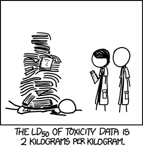

*Source:* xkcd.com

## Exposure vs hazard

Risk of harm arises when **exposure exceeds a threshold of harm**:

$$\text{Outcome} = \underbrace{(E_1 +
E_2)}_{\text{total exposure}} \;-\; \underbrace{H}_{\text{hazard
threshold}}$$

- **Outcome $>$ 0**: potential for harm
- **Outcome $\leq$ 0**: no harm predicted

In practice, both exposure and hazard are **uncertain**. The question is not whether to handle that uncertainty, but how to handle it rigorously.

## Our scenario

A substance can enter the body via two routes. We wish to assess whether combined exposure exceeds a threshold of concern.

| Quantity | Distribution | Mean |
| --- | --- | --- |
| Exposure route 1 ($E_1$) | Gamma(shape = 2, scale = 1) | 2 |
| Exposure route 2 ($E_2$) | Gamma(shape = 3, scale = 1) | 3 |
| Threshold of harm ($H$) | Gamma(shape = 4, scale = 4) + 5 | 21 |

**The central question:** does $E_1 + E_2$ exceed $H$, and with what probability?

# Method 1: the plug-in estimate

## Plug-in: substitute the best estimate

The simplest approach is to replace each uncertain quantity with a **single value** (in this case, the mean):

$$\text{Outcome} = \overline{E}_1 +
\overline{E}_2 - \overline{H} = 2 + 3 - 21 = \mathbf{-16}$$

A negative outcome suggests no harm, with exposure sitting well below the threshold.

**But** both exposure and hazard are uncertain quantities. A single summary value carries no information about how that conclusion might change under realistic variation in the inputs.

## Exercise 1: plug-in estimate

Using the means $\overline{E}_1 = 2$, $\overline{E}_2 = 3$, $\overline{H} = 21$, calculate the plug-in outcome $E_1 + E_2 - H$.

```r
# For a Gamma distribution, E(X) = shape x scale
E1_mean <- 2 * 1      # = 2
E2_mean <- 3 * 1      # = 3
H_mean  <- 4 * 4 + 5  # = 21

plug_in <- E1_mean + E2_mean - H_mean
plug_in
```

## Exercise 1: solution

```r
plug_in <- (2 * 1) + (3 * 1) - (4 * 4 + 5)
plug_in
```

```
#> [1] -16
```

**Answer:** $2 + 3 - 21 = -16$.

The combined exposure sits 16 units below the threshold. This single value carries no information about the uncertainty surrounding that conclusion.

# Method 2: the conservative estimate

[figure not shown]

*Source:* xkcd.com

## Conservative: stack the worst-case percentiles

Instead of means, we use **upper percentiles for exposure** and a **lower percentile for hazard**:

- 95th (or 99th) percentile of $E_1$ and $E_2$: assume high exposure
- 5th (or 1st) percentile of $H$: assume low tolerance

The reasoning is that if even a pessimistic scenario is safe, we may be confident in the conclusion.

**However,** “worst case” has no precise probabilistic meaning in this construction. The likelihood of all inputs simultaneously taking their extreme values is unknown and typically very small.

## Exercise 2: conservative estimate

Simulate the three distributions and calculate conservative estimates at two levels of stringency, then compare the results to the plug-in value.

```r
set.seed(42); N <- 10000
E_1 <- rgamma(N, shape = 2, scale = 1)
E_2 <- rgamma(N, shape = 3, scale = 1)
H   <- rgamma(N, shape = 4, scale = 4) + 5

cons_95 <- quantile(E_1, 0.95) + quantile(E_2, 0.95) - quantile(H, 0.05)
cons_99 <- quantile(E_1, 0.99) + quantile(E_2, 0.99) - quantile(H, 0.01)

c(plug_in = -16, cons_95 = cons_95, cons_99 = cons_99)
```

## Exercise 2: solution

```r
c(plug_in = -16, cons_95 = cons_95, cons_99 = cons_99)
```

[output not shown]

**plug-in: −16 | conservative (95th): ≈ −3 | conservative (99th): ≈ +2**

The 99th-percentile assessment reverses the conclusion, yet we have no means of assigning a probability to that outcome. We do not know where in the distribution we are.

## The problem with conservative stacking

Combining extreme percentiles **compounds the conservatism** in an uncontrolled way:

> “What is the probability of being simultaneously at the 99th percentile of exposure and the 1st percentile of hazard?”
- Each input is at its extreme
- The combined outcome is more extreme still
- We have **no means of assigning a probability** to the outcome

Conservative stacking does not yield a probability of harm.

It yields an unknown percentile of an unknown distribution.

# The required effort…

[figure not shown]

*Source:* xkcd.com

## What a probabilistic model (probably) requires

Moving from a plug-in estimate to a well-characterised mathematical simulation is not a small step. It requires:

- **Input distributions**: good data or structured elicitation from credible experts for every uncertain quantity in the model
- **A clearly defined question**: the scope, the population, the endpoint and the time horizon, stated precisely before the analysis begins
- **A documented model structure**: the assumptions that govern how inputs combine, made explicit and defensible
- **Sensitivity analysis**: identifying which inputs drive the result, so that further investigation is targeted where it will have most impact
- **Validation and review**: checking that the model behaves sensibly, and that the conclusions are auditable by someone not involved in the analysis
- **Communication**: reporting results in a form that a decision-maker can understand and act upon

## Where the effort goes

In practice, the computation itself is often the smallest part of the work.

The time-consuming parts are almost always **upstream**: defining the question with sufficient precision, gathering and cleaning input data and eliciting and documenting expert judgements.

Constructing a model structure that stakeholders will trust takes time that is easy to underestimate. A technically sophisticated simulation built on a vaguely defined question is, in practice, of limited value: a model is only as good as the question it was built to answer.

This is why shortcuts persist. Plug-in estimates and conservative stacking are quick to produce and easy to explain. Acknowledging that they provide an incomplete picture is the first step; building the capacity and institutional support to do better is the longer-term challenge.

## Discussion: effort and capacity

Consider the steps listed in the previous slide in the context of your own research or professional practice.

1. Which of these steps would be most straightforward for you to carry out? Which would require the most support or new capability?
2. Are there circumstances in which a quick, transparent plug-in estimate accompanied by an honest statement of its limitations is the most defensible choice?

# Why is uncertainty important?

[figure not shown]

*Source:* xkcd.com

## Why is uncertainty important?

- Uncertainty is **information**: it describes what we know and, equally, what we do not
- Ignoring uncertainty produces false confidence (in the plug-in case) or excessive and unquantified caution (in the conservative case)
- A distribution of outcomes allows decision-makers to reason about the **full range of plausible scenarios**
- Different decisions have different tolerances for risk; quantified uncertainty is required to engage with those tolerances in a principled way
- Without uncertainty, we cannot meaningfully compare options or identify where further investigation would be most valuable

## Uncertainty and variability are not the same thing

**Uncertainty** is epistemic: it reflects limitations in available knowledge and is, in principle, reducible by further research, better data or more refined modelling.

**Variability** is aleatory: it describes genuine heterogeneity within a population or system. The distribution of body weights across an exposed population, for instance, cannot be reduced by gathering more information because it is a property of the world rather than of our knowledge of it.

## Why the distinction matters

This distinction has direct consequences for how conclusions should be communicated and acted upon.

If a wide probability range reflects **uncertainty**, the appropriate response may be to commission further studies. If the same range reflects **variability**, additional research will not narrow it; the decision-maker must instead determine whether the distribution of outcomes across the population is acceptable.

## Discussion: uncertainty and variability in your work

In pairs or small groups, consider a source of imprecision or unknowns in your own research.

1. Is this an **uncertainty** (something you could reduce by gathering more data or doing more analysis) or a **variability** (a genuine property of the system that further research will not narrow)?
2. Does the distinction matter for how you would communicate your findings to a decision-maker or funder?

## Distributions capture our state of knowledge

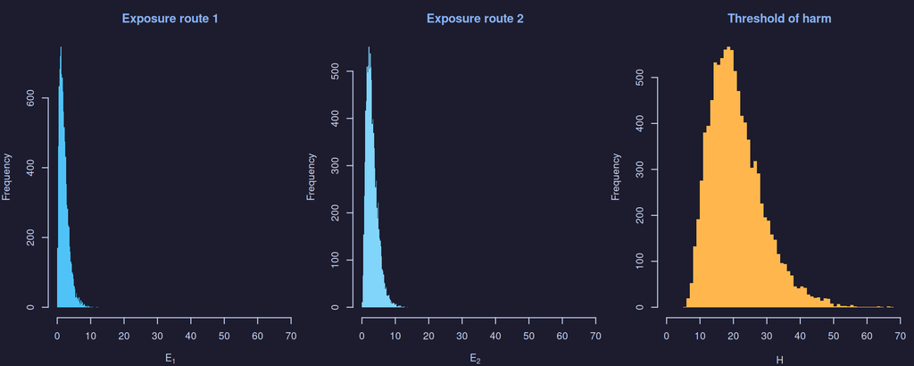

Each distribution encodes both the most plausible value and the realistic range of each quantity.

# Method 3: Monte Carlo simulation

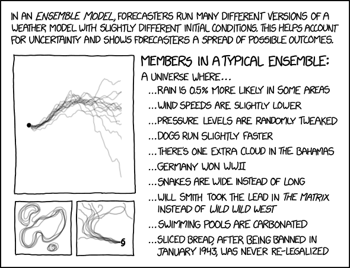

*Source:* xkcd.com

## Monte Carlo: propagating uncertainty

Rather than combining point estimates, we **sample from all distributions simultaneously** and combine the samples:

$$\text{Outcome}_i = E_{1,i} + E_{2,i} -
H_i, \qquad i = 1, \ldots, N$$

This produces a **full distribution of outcomes**, from which the probability of harm is read directly as the proportion of simulations in which the outcome exceeds zero.

Probability of harm = proportion of simulations where (Outcome > 0)

## Exercise 3: Monte Carlo simulation

Run the simulation below, plot the resulting outcome distribution and calculate the probability of harm. Note where the plug-in estimate of −16 falls in the distribution.

```r
set.seed(42); N <- 10000
E_1 <- rgamma(N, shape = 2, scale = 1)
E_2 <- rgamma(N, shape = 3, scale = 1)
H   <- rgamma(N, shape = 4, scale = 4) + 5

outcomes <- E_1 + E_2 - H

hist(outcomes, breaks = 60, col = "#4FC3F7",
     main = "Distribution of outcomes", xlab = "E1 + E2 - H")
abline(v = 0, col = "red", lwd = 2)

mean(outcomes > 0)  # probability of harm
```

## Exercise 3: solution

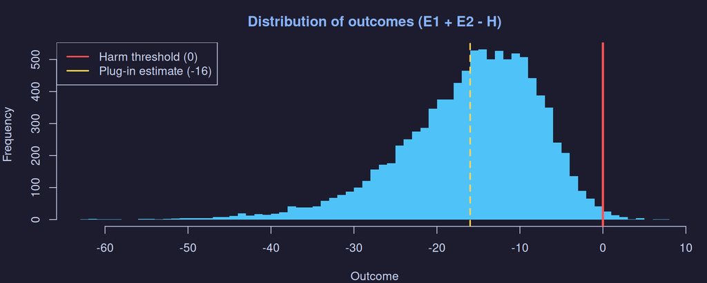

The probability of harm is approximately **0.5%**: low, but now precisely quantified.

## Comparing the three approaches

| Method | Outcome | What it provides |
| --- | --- | --- |
| Plug-in | −16 | A single summary value based on central estimates |
| Conservative (95th/5th) | ≈ −3 | A screening calculation based on selected tail percentiles |
| Conservative (99th/1st) | ≈ +2 | A more extreme screening calculation based on selected tail percentiles |
| **Monte Carlo** | **~0.5% P(harm)** | **A simulated outcome distribution and an estimated probability of harm** |

Monte Carlo directly estimates a probability of harm, which is a quantity decision-makers require to reason about risk.

# The effect of correlation

## When things are not independent

In many realistic scenarios, variables are driven by shared underlying factors: for instance, the amount of time spent in a particular environment. In such cases:

- When $E_1$ is high, $E_2$ tends to be high also: **positive correlation**.
- Treating the routes as independent **understates** the joint tail risk.

Ignoring correlation where it is present will typically yield a falsely reassuring probability of harm.

## What correlation looks like

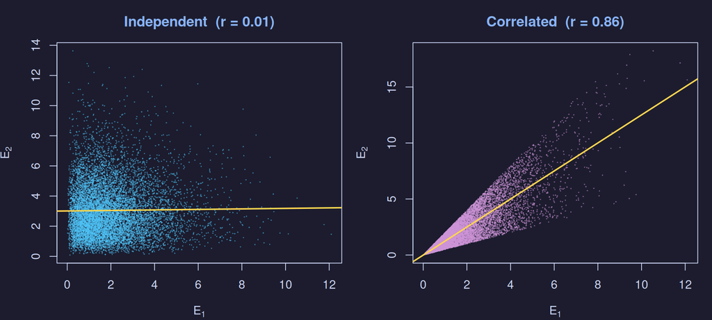

With independence, knowing $E_1$ tells us nothing about $E_2$. With correlation, high values of $E_1$ are systematically accompanied by high values of $E_2$, inflating the joint tail.

## Exercise 4: correlated Monte Carlo

Introduce a positive dependence between $E_1$ and $E_2$ as shown, check the resulting correlation and compare the probability of harm to the independent case.

```r
set.seed(42); N <- 10000
E_1  <- rgamma(N, shape = 2, scale = 1)
H    <- rgamma(N, shape = 4, scale = 4) + 5

E_2c <- runif(N, 0.5, 2) * E_1  # E_2 now proportional to E_1

cor(E_1, E_2c)

outcomes_c <- E_1 + E_2c - H
mean(outcomes_c > 0)
```

## Exercise 4: solution

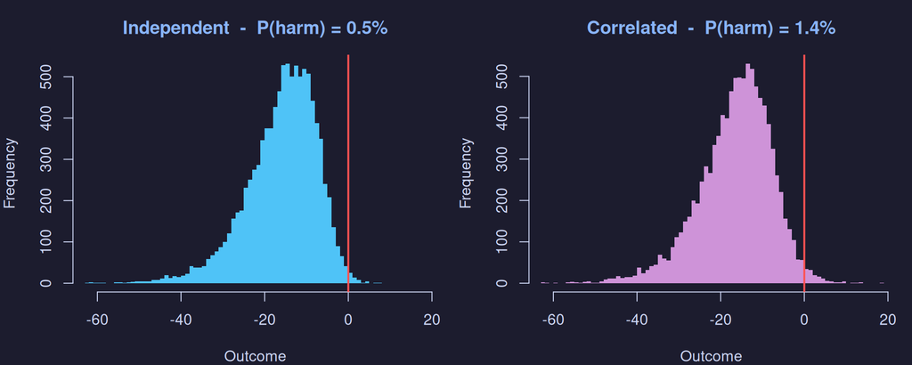

The correlation of approximately 0.86 widens the outcome distribution and raises the probability of harm (substantially).

# Defining the question precisely

[figure not shown]

*Source:* xkcd.com

## Sources of ambiguity in our risk question

Consider the statement: *“Exposure to this substance is unlikely to cause harm.”*

- **Who is exposed?** The average adult? A child? A susceptible subpopulation?
- **What counts as harm?** A clinical endpoint? A subclinical biomarker change? Any detectable effect?
- **Over what time period?** A single acute exposure? Lifetime chronic exposure?
- **At what dose?** The typical dietary intake? The 95th-percentile intake?
- **How unlikely is “unlikely”?** Without a number, the reader cannot know.

Each of these ambiguities is, in effect, an unstated assumption. Making them explicit is not a weakness in the analysis; it is a precondition for the analysis being useful.

## Exercise: defining the question

Return to the question you wrote at the start of the session.

1. Rewrite the question to make it as precise as possible, explicitly stating any assumptions that are currently implicit.
2. Identify any remaining ambiguities in the question, and how they might affect the analysis.
3. Consider how you would communicate the question and its assumptions to a decision-maker or stakeholder.

## The EFSA four-step procedure

The EFSA framework identifies a four-step procedure applicable to all assessments:

1. **Identify** the relevant sources of uncertainty
2. **Characterise** each source in terms of its direction and magnitude
3. **Combine** the characterised sources into an overall expression of uncertainty
4. **Report** that uncertainty in a form appropriate to the decision context

Step 1 requires a well-defined question. In practice, ambiguities in phrasing embed hidden assumptions that can substantially alter the numerical conclusion.

## Exercise: identifying uncertainties

Back to your question again.

1. **List the uncertainties**: using the table of uncertainty sources from the next slide, identify which types of uncertainty are present in your rewritten question.
2. **State your overall uncertainty**: using the EFSA probability scale, where on that scale would you place your current state of knowledge about the answer to your question?

## Sources of uncertainty: a reference table

| Source | Description | Example |
| --- | --- | --- |
| Measurement error | Imprecision in observed data | Analytical variability in monitoring |
| Natural variability | Genuine heterogeneity in the system | Body weight distribution across a population |
| Model uncertainty | Structural assumptions that may not hold | Assumed linearity of dose-response |
| Expert judgement | Probability assigned in the absence of data | Plausible range for an unstudied substance |
| Scenario uncertainty | Ambiguity about which situation is relevant | Which exposure pathway dominates? |
| Unknown unknowns | Factors not yet identified | Interactions with co-exposures not assessed |

## Why is transparency important?

- A number is only as good as the **assumptions behind it**: who chose these distributions, on what basis and using what evidence?
- Transparency allows others to **challenge, audit and improve** the analysis
- It reveals where additional data would most reduce uncertainty, and therefore where further investigation is warranted
- It distinguishes **what was measured** from **what was assumed**
- Without transparency, a result cannot be properly scrutinised or reproduced; the analysis is, in effect, a black box
- Ultimately, transparency is what makes an analysis **trustworthy** and fit-for-purpose as a contribution to a decision-making process

## Conditionality: all conclusions are provisional

A principle that follows directly from transparency is **conditionality**: every scientific conclusion is conditional on the evidence base and the assessors available at the time the assessment is conducted.

The EFSA framework requires that assessments state this explicitly:

- Which sources of uncertainty were considered
- Which were not, and on what grounds
- A qualitative acknowledgement of any unknown unknowns that lie outside the scope of the analysis

## The danger of unconditional conclusions

A conclusion presented as unconditional, when in fact it rests on a specific and potentially contested set of assumptions, is not more authoritative than a conditional one.  
**It is simply less honest.**

# The role of quantitative analysis

[figure not shown]

*Source:* xkcd.com

## Numbers are not the decision

*“The purpose of models is not to fit data, but to sharpen the question.”*  
Samuel Karlin

Quantitative analyses **inform** decisions; they provide structured, reproducible evidence. They do not **replace** judgement, values or regulatory context.

They **can mislead** if their assumptions are hidden or not communicated.

They are also **iterative**: a model improves through challenge, revision and the incorporation of new data.

## The limits of the numbers

- Models are **simplifications**; they cannot capture every relevant feature of the system
- A probability of harm of 2% is not the same as “safe”: its acceptability depends on the severity and reversibility of the harm as well as who bears the risk
- Aggregating uncertainty across many inputs can, in some circumstances, understate or overstate the overall risk
- The **model boundary** matters; what was not modelled is as important as what was
- Sensitivity analysis and scenario testing are essential for identifying where conclusions are fragile

A well-constructed uncertainty distribution is honest about what we know. A point estimate conceals what we do not.

## Exercise 5: reflection

**Group discussion.** Working through the scenario we have explored:

1. If you were presenting findings to a regulator, which result would you lead with: plug-in, conservative, or Monte Carlo? What is your justification?
2. What additional information would you want before reaching a conclusion?
3. If the probability of harm were 0.5%, would that be acceptable? Does your answer depend on the nature of the harm or on who is exposed?

## Closing discussion

**Group reflection.**

1. What remains the most significant barrier to using quantitative methods more rigorously in your own work: data, expertise, time, institutional support or something else?
2. Is there a role for the kind of quantitative analysis we have discussed today in work that is primarily qualitative in character?

## Key messages: methods

- Numbers enable comparison and accountability, but they must be **honest about their basis**
- Verbal probability expressions are ambiguous and directional; **numbers anchored to verbal terms** are substantially less so
- Uncertainty is not a weakness in an analysis: it is **information**
- Conservative stacking yields an unknown percentile, not a probability of harm
- Monte Carlo simulation propagates uncertainty and delivers a **quantified probability**
- Correlation between inputs can substantially change the result and must be explicitly considered

## Key messages: practice

- The quality of a quantitative analysis depends on the clarity of the **question it addresses**, and that question is harder to state precisely than it first appears
- Structured expert elicitation provides a principled bridge between qualitative expertise and quantitative models; the two traditions share more common ground than is often assumed
- Producing a proper probabilistic model requires substantial effort: defining the question, gathering input data, eliciting expert judgements, constructing the model and communicating the results honestly. That effort is worthwhile, but it should not be underestimated
- Quantitative results are **evidence for decision-makers**; they are not decisions in themselves

# References

Budescu, D. V., Por, H.-H., Broomell, S. B. & Smithson, M. (2014). The interpretation of IPCC probabilistic statements around the world. *Nature Climate Change*, 4(6), 508–512.

Clark, D. A. (1990). Verbal uncertainty expressions: a critical review of two decades of research. *Current Psychology*, 9(3), 203–235.

EFSA Scientific Committee (2018). Guidance on Uncertainty in EFSA Scientific Assessment. *EFSA Journal*, 16(1), 5123.

EFSA Scientific Committee (2019). Guidance on Communication of Uncertainty in Scientific Assessments. *EFSA Journal*, 17(1), 5520.

Gosling, J. P. (2018). SHELF: the Sheffield Elicitation Framework. In L. C. Dias, A. Morton & J. Quigley (eds.), *Elicitation: the science and art of structuring judgement*. Cham: Springer, pp. 61–93.

Teigen, K. H. (2023). Dimensions of uncertainty communication: what is conveyed by verbal terms and numeric ranges. *Current Psychology*, 42, 29122–29137.

Van der Bles, A. M. et al. (2019). Communicating uncertainty about facts, numbers and science. *Royal Society Open Science*, 6(5), 181870.